# TP3 Linear Models

A.V Hurtado Quiceno

2/5/2023

# Descriptive

## Corrplot

On regarde les corrélations entre et les variables explicatives avec le corrplot.

|  | maxO3 | T6 | T9 | T12 | T15 | T18 | Ne6 | Ne9 | Ne12 | Ne15 | Vx | maxO3v |
| --- | --- | --- | --- | --- | --- | --- | --- | --- | --- | --- | --- | --- |
| maxO3 | 1.0000000 | 0.1281311 | 0.3943804 | 0.4922408 | 0.4941654 | 0.4601175 | -0.3852286 | -0.5203974 | -0.5171337 | -0.4384199 | 0.3497160 | 0.7417078 |
| T6 | 0.1281311 | 1.0000000 | 0.8295917 | 0.7185304 | 0.6857276 | 0.6911332 | 0.1428955 | 0.0391793 | -0.0557605 | -0.0864578 | -0.0900561 | 0.1887631 |
| T9 | 0.3943804 | 0.8295917 | 1.0000000 | 0.9365206 | 0.8963120 | 0.8843675 | -0.2614440 | -0.3654553 | -0.3639261 | -0.3246449 | 0.1187455 | 0.3258910 |
| T12 | 0.4922408 | 0.7185304 | 0.9365206 | 1.0000000 | 0.9613127 | 0.9324465 | -0.3072917 | -0.4548876 | -0.5118605 | -0.4344505 | 0.2110709 | 0.3703471 |
| T15 | 0.4941654 | 0.6857276 | 0.8963120 | 0.9613127 | 1.0000000 | 0.9667778 | -0.3005149 | -0.4506817 | -0.5312179 | -0.5212225 | 0.2529042 | 0.3618572 |
| T18 | 0.4601175 | 0.6911332 | 0.8843675 | 0.9324465 | 0.9667778 | 1.0000000 | -0.2686855 | -0.4080834 | -0.4897529 | -0.4873511 | 0.2649054 | 0.3293503 |
| Ne6 | -0.3852286 | 0.1428955 | -0.2614440 | -0.3072917 | -0.3005149 | -0.2686855 | 1.0000000 | 0.6839038 | 0.5308008 | 0.4198220 | -0.2726603 | -0.2144222 |
| Ne9 | -0.5203974 | 0.0391793 | -0.3654553 | -0.4548876 | -0.4506817 | -0.4080834 | 0.6839038 | 1.0000000 | 0.7568688 | 0.5792770 | -0.3776422 | -0.3210610 |
| Ne12 | -0.5171337 | -0.0557605 | -0.3639261 | -0.5118605 | -0.5312179 | -0.4897529 | 0.5308008 | 0.7568688 | 1.0000000 | 0.7532229 | -0.3690895 | -0.3087800 |
| Ne15 | -0.4384199 | -0.0864578 | -0.3246449 | -0.4344505 | -0.5212225 | -0.4873511 | 0.4198220 | 0.5792770 | 0.7532229 | 1.0000000 | -0.3374877 | -0.2632927 |
| Vx | 0.3497160 | -0.0900561 | 0.1187455 | 0.2110709 | 0.2529042 | 0.2649054 | -0.2726603 | -0.3776422 | -0.3690895 | -0.3374877 | 1.0000000 | 0.2033773 |
| maxO3v | 0.7417078 | 0.1887631 | 0.3258910 | 0.3703471 | 0.3618572 | 0.3293503 | -0.2144222 | -0.3210610 | -0.3087800 | -0.2632927 | 0.2033773 | 1.0000000 |

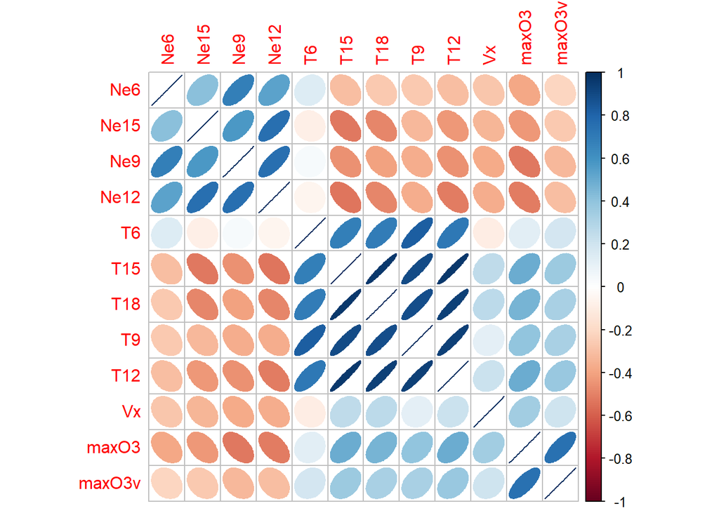

Dans ce graphique, nous avons une corrélation élevée avec la couleur bleue, et aussi à partir de ce graphique particulier de type ellipse, nous pouvons vérifier si la corrélation est positive ou négative.

# Modele avec tous les variables explicatives

Pour commencer, nous considérons le modèle avec toutes les variables explicatives comme suit :

```r
res <- lm(maxO3~ T6 + T9 + T12 + T15 + T18 +Ne6 +Ne9 +Ne12 + Ne15 + Vx + maxO3v, data=ozone)
summary(res)
```

```
##
## Call:
## lm(formula = maxO3 ~ T6 + T9 + T12 + T15 + T18 + Ne6 + Ne9 +
##     Ne12 + Ne15 + Vx + maxO3v, data = ozone)
##
## Residuals:
##     Min      1Q  Median      3Q     Max
## -67.609  -9.086   0.394   9.803  50.380
##
## Coefficients:
##             Estimate Std. Error t value Pr(>|t|)
## (Intercept) 27.04156    3.35732   8.055 1.73e-15 ***
## T6          -1.55395    0.27927  -5.564 3.17e-08 ***
## T9           0.05605    0.42754   0.131   0.8957
## T12          1.33995    0.40647   3.297   0.0010 **
## T15          0.21801    0.41868   0.521   0.6027
## T18          0.21181    0.32040   0.661   0.5087
## Ne6         -0.09098    0.21717  -0.419   0.6753
## Ne9         -0.68611    0.31040  -2.210   0.0272 *
## Ne12        -0.80565    0.35810  -2.250   0.0246 *
## Ne15        -0.34460    0.29504  -1.168   0.2430
## Vx           0.55747    0.13834   4.030 5.90e-05 ***
## maxO3v       0.58823    0.01659  35.449  < 2e-16 ***
## ---
## Signif. codes:  0 '***' 0.001 '**' 0.01 '*' 0.05 '.' 0.1 ' ' 1
##
## Residual standard error: 15.17 on 1354 degrees of freedom
## Multiple R-squared:  0.689,  Adjusted R-squared:  0.6865
## F-statistic: 272.8 on 11 and 1354 DF,  p-value: < 2.2e-16
```

$\textbf{Observation}:$ Le $R^2$ est plutôt bon mais beaucoup de variables ne sont pas significatives

# Analyse et normalité des résidus d’estimation, résidus studentisés

Examinons maintenant les résidus d’estimation (tracez les résidus en fonction des valeurs ajustées et commentez le graphique ainsi obtenu). Examinons maintennat la normalité des résidus d’estimation:

## Normalité des résidus d’estimation

- QQPLOT

Les résidus ne suivent pas la ligne normale dans le tracé QQ, en particulier dans la queue inférieure, ce qui suggère que les données ne sont pas normalement distribuées.

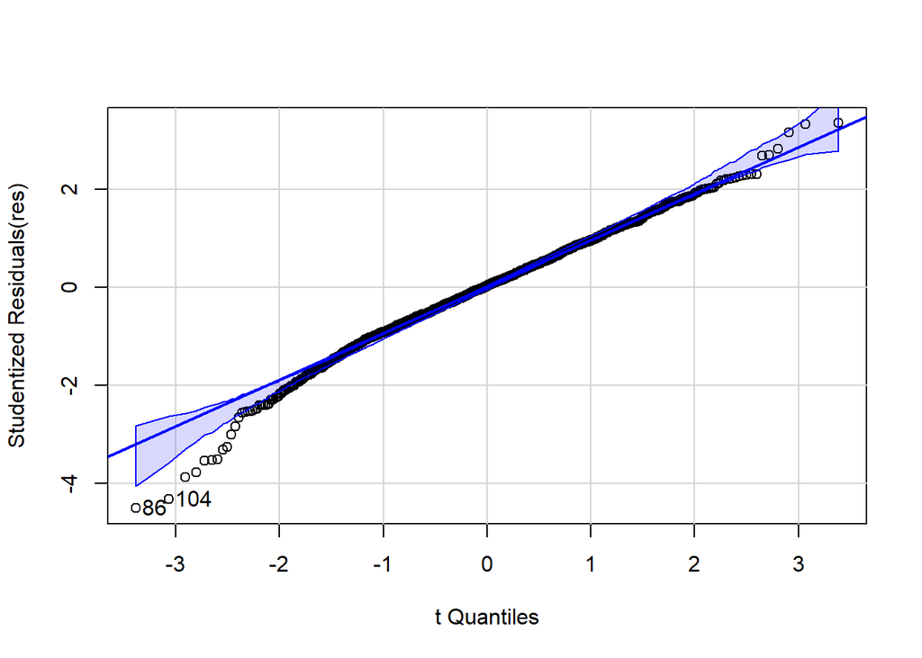

```
## [1]  86 104
```

```r
qqPlot(res)
```

```r
#plot(res,which=2,sub="",main="")
#abline(0,1)
```

- Shapito Test for Normality

Laisser les hyphotesis nuls et alternatifs comme suit :

$$\begin{equation}
\begin{split}
H_{0} &: \text{les données sont normalement distribuées}\\
H_{1} &: \text{les données ne sont pas normalement distribuées}
\end{split}
\end{equation}$$

Nous effectuons un test Shapiro-Wilk pour tester la normalité des résidus comme suit

```r
resi <- residuals(res)
shapiro.test(resi)
```

```
##
##  Shapiro-Wilk normality test
##
## data:  resi
## W = 0.99043, p-value = 8.97e-08
```

Puisque votre $p-value=8.97e-08$ est beaucoup plus petite que 0.05, nous pouvons conclure qu’il y a des preuves solides pour rejeter l’hypothèse nulle et conclure que vos données ne sont pas normalement distribuées.

- Kolmogorov Test: La p valeur du test de Kolmogorov est inférieure à 0,05, ce qui indique que les données ne sont pas normalement distribuées.

```r
ks.test(resi, 'pnorm')
```

```
##
##  Asymptotic one-sample Kolmogorov-Smirnov test
##
## data:  resi
## D = 0.43632, p-value < 2.2e-16
## alternative hypothesis: two-sided
```

## Histogram

- La curve est etaler, et aussi les valeurs sont entre -60 et 60, pas de -2 et 2, donc ce n’est pas normal.

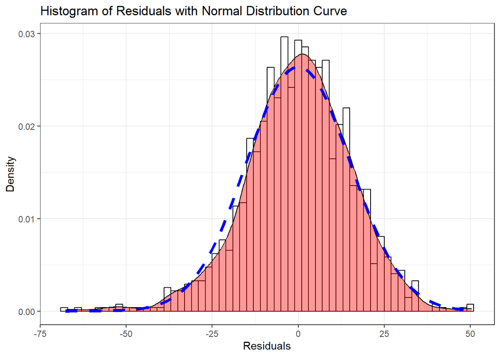

```r
#hist(residuals(res),xlab="residus d estimation",main="Histogramme des residus",breaks=20)
ggplot(data = data.frame(residuals = residuals(res)), aes(x = residuals)) +
  geom_histogram(binwidth = 2, aes(y = after_stat(density)),
                 color = "black", fill = "white") +
  geom_density(alpha = 0.4, fill = "red") +
  stat_function(fun = dnorm, args = list(mean = mean(residuals(res)), sd = sd(residuals(res))), color = "blue", linetype = "dashed", size = 1.5) +
  labs(x = "Residuals", y = "Density", title = "Histogram of Residuals with Normal Distribution Curve") +
  theme_bw()
```

## Résidus studentisées

En utilisant la fonction rstudent pour représenter les résidus studentisés, nous pouvons remarquer que les résidus qui tombent en dehors de l’intervalle de $[-2,2]$ peuvent signaler la présence de valeurs aberrantes potentielles ou d’observations influentes qui ont une plus grande influence sur l’ajustement du modèle. Autrement dit, ces résidus qui sont en dehors de la plage mentionnée peuvent être considérés comme des outliers.

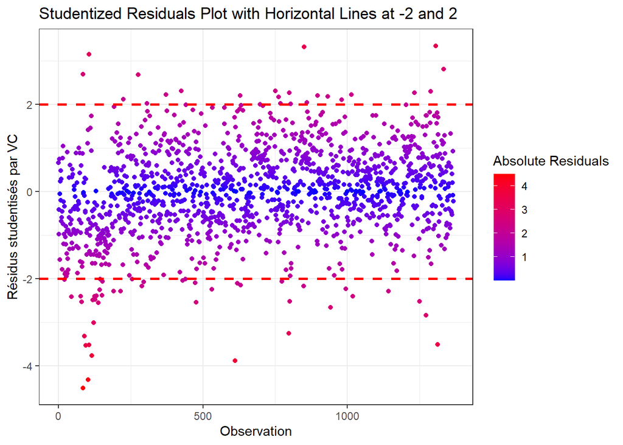

```r
#With R
#plot(rstudent(res),ylab="Résidus studentisés par VC")
#abline(h=c(-2,2))

#With ggplot2 package
ggplot(data.frame(residuals = rstudent(res)), aes(x = seq_along(residuals), y = residuals, color = abs(residuals))) +
  geom_point() +
  geom_hline(yintercept = c(-2, 2), linetype = "dashed", color = "red", size = 1) +
  scale_color_gradient(low = "blue", high = "red", name = "Absolute Residuals") +
  labs(x = "Observation", y = "Résidus studentisés par VC", title = "Studentized Residuals Plot with Horizontal Lines at -2 and 2") +
  theme_bw()
```

# Variance constante des résidus

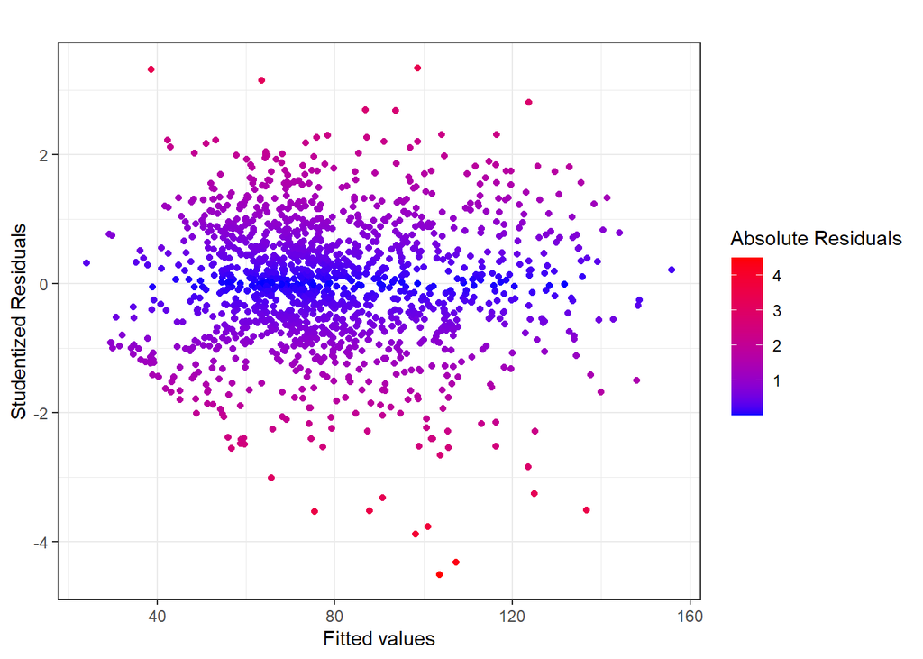

```r
ggplot(data.frame(residuals = rstudent(res), fitted = fitted(res)),
       aes(x = fitted, y = residuals, color = abs(residuals))) +
  geom_point() +
  scale_color_gradient(low = "blue", high = "red", name = "Absolute Residuals") +
  labs(x = "Fitted values", y = "Studentized Residuals",
       title = " ") +
  theme_bw()
```

- Test de Breusch-Pagan par heteroscedasticity

$$\begin{equation}
\begin{split}
H_{0} &: \text{the variance of the errors is constant
(homoscedasticity)}\\
H_{1} &: \text{the variance of the errors is not constant
(heteroscedasticity)}
\end{split}
\end{equation}$$

```r
btest <- bptest(res)
btest
```

```
##
##  studentized Breusch-Pagan test
##
## data:  res
## BP = 53.229, df = 11, p-value = 1.631e-07
```

since the p-values is $1.631e-07$ less that 0.05, we reject the null hypothesis and conclude that there is evidence of heteroscedasticity

# Détection des points leviers et influents

Pour détercter les points leviers, on regarde les éléments diagonaux hii de la matrice hat. Cela est réalisé avec la fonction hat avec l’option intercept=TRUE. Représenter les hii pour ce jeu de données et comparer avec les valeurs seuil données dans le cours

## Elements $h_{ii}$ de Hat matrice

```r
ozone1 <- ozone[,-1]
h_ii <- hat(ozone[,-1], intercept = TRUE)
head(h_ii)
```

```
## [1] 0.024874811 0.019170808 0.010689818 0.020120497 0.016025095 0.007305269
```

```r
green <- which(h_ii > 0.05)
```

## Plot de $h_{ii}$

Nous avons beaucoup de points qui ont une valeur $h_{ii}$ supérieure à:

- Velleman et Wellsch :

$$3* (p+1)/n \approx 0.029$$

- Hoaglin et Welsch :

$$2*(p+1)/n\approx 0.019$$

et nous avons un point unique supérieur à 0,05 qui est en bleu.

$\textbf{Observation:}$

Mais remarquez que je n’ai trouvé aucun point plus grand que $0.5$.

```
## The number of hii that are greater than 0.5 is  FALSE
```

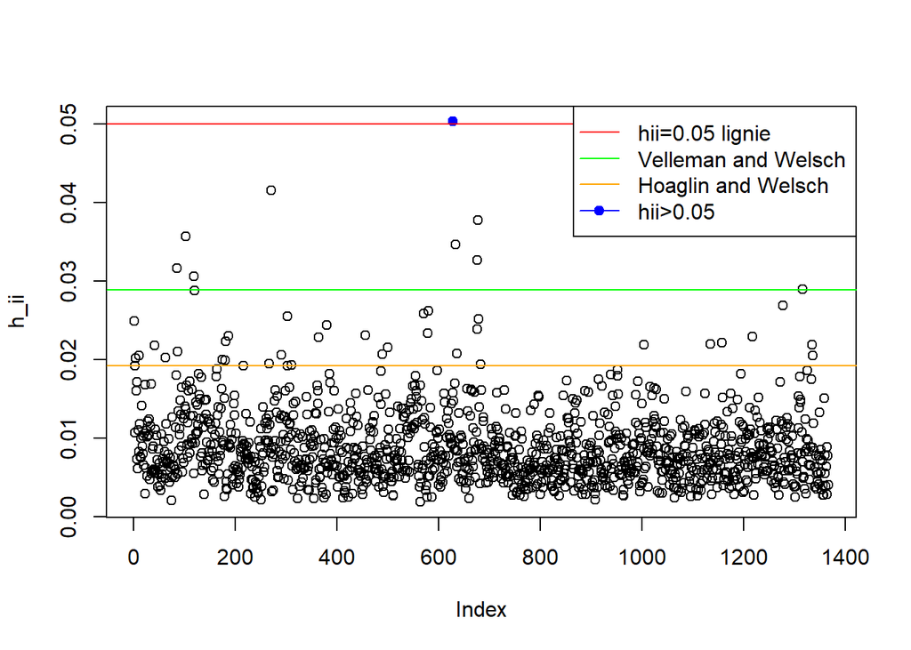

```r
plot(h_ii)
points(green, h_ii[green], col="blue", pch=19)
abline(h=0.05, col="red")
abline(h=3*(13)/1353, col="green")
abline(h=2*(13)/1353, col="orange")
legend("topright", legend=c("hii=0.05 lignie ", "Velleman and Welsch", "Hoaglin and Welsch", "hii>0.05"), col=c("red", "green", "orange", "blue"), lty=1, pch=c(NA, NA, NA, 19))
```

## Distance de Cook

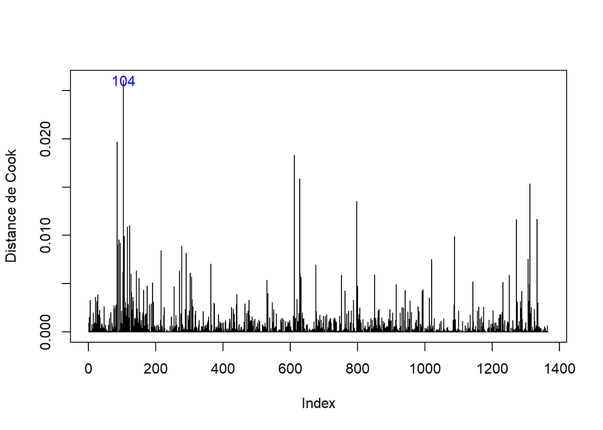

# Recherche du meilleur Modèle

Comme nous l’avons vu en cours, il existe de nombreux critères différents pour comparer plusieurs modèles entre eux et sélectionner le “plus performant” (la performance étant parfois définie de manière différente selon les critères). Les critères de sélection sont:

- Le $R^{2}$ ajusté (qui est founi par la fonction summary).
- Le critère d’information d’Akaike.
- Le critèere du BIC.

## Best model in terms of the `SCR`

- Le but est de comparer les modèles entre eux, pour cela nous calculons le `BIC`, le `$R^{2}$` et la méthode `AIC`.

| (Intercept) | T6 | T9 | T12 | T15 | T18 | Ne6 | Ne9 | Ne12 | Ne15 | Vx | maxO3v |
| --- | --- | --- | --- | --- | --- | --- | --- | --- | --- | --- | --- |
| TRUE | FALSE | FALSE | FALSE | FALSE | FALSE | FALSE | FALSE | FALSE | FALSE | FALSE | TRUE |
| TRUE | FALSE | FALSE | FALSE | FALSE | FALSE | FALSE | FALSE | TRUE | FALSE | FALSE | TRUE |
| TRUE | TRUE | FALSE | TRUE | FALSE | FALSE | FALSE | FALSE | FALSE | FALSE | FALSE | TRUE |
| TRUE | TRUE | FALSE | TRUE | FALSE | FALSE | FALSE | FALSE | TRUE | FALSE | FALSE | TRUE |
| TRUE | TRUE | FALSE | TRUE | FALSE | FALSE | FALSE | FALSE | TRUE | FALSE | TRUE | TRUE |
| TRUE | TRUE | FALSE | TRUE | FALSE | FALSE | FALSE | TRUE | TRUE | FALSE | TRUE | TRUE |
| TRUE | TRUE | FALSE | TRUE | TRUE | FALSE | FALSE | TRUE | TRUE | FALSE | TRUE | TRUE |
| TRUE | TRUE | FALSE | TRUE | FALSE | TRUE | FALSE | TRUE | TRUE | TRUE | TRUE | TRUE |
| TRUE | TRUE | FALSE | TRUE | TRUE | TRUE | FALSE | TRUE | TRUE | TRUE | TRUE | TRUE |
| TRUE | TRUE | FALSE | TRUE | TRUE | TRUE | TRUE | TRUE | TRUE | TRUE | TRUE | TRUE |

## Critère AIC

- À partir du graphique suivant, nous pouvons voir que le modèle qui convient le mieux à nos données est celui qui comporte $7$ variables (representer par darkblue), puisque c’est celui qui a la plus petite valeur pour `AIC`.

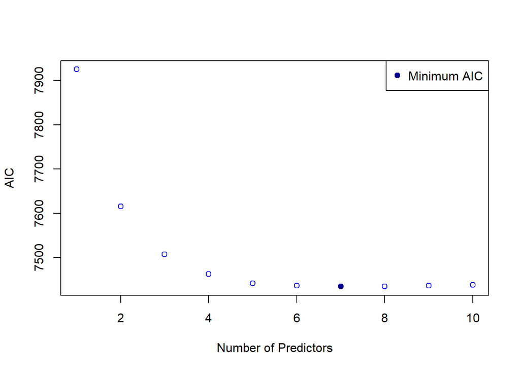

```r
plot(AIC_values ~ seq_along(rs$rsq), xlab = "Number of Predictors", ylab = "AIC", col="blue")
points(minimum, AIC_values[minimum], col="darkblue", pch=19)

legend("topright", legend="Minimum AIC", col="darkblue", pch=19)
```

- Nous pouvons confirmer ce que nous avons vu dans le graphique ci-dessus avec la fonction `step`. Pour ce cas ici on va a spécifier l’option $k=2$:

```
## Start:  AIC=7440.62
## maxO3 ~ T6 + T9 + T12 + T15 + T18 + Ne6 + Ne9 + Ne12 + Ne15 +
##     Vx + maxO3v
##
##          Df Sum of Sq    RSS    AIC
## - T9      1         4 311482 7438.6
## - Ne6     1        40 311518 7438.8
## - T15     1        62 311540 7438.9
## - T18     1       101 311578 7439.1
## - Ne15    1       314 311791 7440.0
## <none>                311478 7440.6
## - Ne9     1      1124 312602 7443.5
## - Ne12    1      1164 312642 7443.7
## - T12     1      2500 313978 7449.5
## - Vx      1      3735 315213 7454.9
## - T6      1      7123 318600 7469.5
## - maxO3v  1    289086 600564 8335.5
##
## Step:  AIC=7438.63
## maxO3 ~ T6 + T12 + T15 + T18 + Ne6 + Ne9 + Ne12 + Ne15 + Vx +
##     maxO3v
##
##          Df Sum of Sq    RSS    AIC
## - Ne6     1        57 311538 7436.9
## - T15     1        61 311542 7436.9
## - T18     1       107 311589 7437.1
## - Ne15    1       313 311794 7438.0
## <none>                311482 7438.6
## - Ne12    1      1206 312688 7441.9
## - Ne9     1      1255 312737 7442.1
## - T12     1      3525 315007 7452.0
## - Vx      1      3731 315213 7452.9
## - T6      1     13019 324500 7492.6
## - maxO3v  1    289084 600565 8333.5
##
## Step:  AIC=7436.88
## maxO3 ~ T6 + T12 + T15 + T18 + Ne9 + Ne12 + Ne15 + Vx + maxO3v
##
##          Df Sum of Sq    RSS    AIC
## - T15     1        57 311596 7435.1
```

[output cut: 21 more lines]

```
## - T6      1     14636 326232 7495.8
## - maxO3v  1    289925 601520 8331.6
##
## Step:  AIC=7434.99
## maxO3 ~ T6 + T12 + Ne9 + Ne12 + Ne15 + Vx + maxO3v
##
##          Df Sum of Sq    RSS    AIC
## <none>                312020 7435.0
## - Ne15    1       836 312856 7436.6
## - Ne12    1      1055 313075 7437.6
## - Ne9     1      1649 313669 7440.2
## - Vx      1      4489 316509 7452.5
## - T6      1     14227 326247 7493.9
## - T12     1     23809 335829 7533.4
## - maxO3v  1    289834 601853 8330.4
```

```
##
## Call:
## lm(formula = maxO3 ~ T6 + T12 + Ne9 + Ne12 + Ne15 + Vx + maxO3v,
##     data = ozone)
##
## Residuals:
##     Min      1Q  Median      3Q     Max
## -67.721  -9.010   0.272   9.746  51.019
##
## Coefficients:
##             Estimate Std. Error t value Pr(>|t|)
## (Intercept) 27.81506    3.13711   8.866  < 2e-16 ***
## T6          -1.52173    0.19339  -7.869 7.26e-15 ***
## T12          1.77848    0.17471  10.180  < 2e-16 ***
## Ne9         -0.72365    0.27009  -2.679  0.00747 **
## Ne12        -0.73814    0.34449  -2.143  0.03232 *
## Ne15        -0.51035    0.26754  -1.908  0.05665 .
## Vx           0.59534    0.13468   4.420 1.06e-05 ***
## maxO3v       0.58690    0.01652  35.517  < 2e-16 ***
## ---
## Signif. codes:  0 '***' 0.001 '**' 0.01 '*' 0.05 '.' 0.1 ' ' 1
##
## Residual standard error: 15.16 on 1358 degrees of freedom
## Multiple R-squared:  0.6885, Adjusted R-squared:  0.6869
## F-statistic: 428.8 on 7 and 1358 DF,  p-value: < 2.2e-16
```

- Dans ce cas, le modèle avec le AIC le plus bas est
  $$\left( \mathcal{M}_{A I C} \right): \quad \operatorname{maxO} 3=\beta_0
  + \beta_01 T 6+ \beta_2 T 12+ \beta_3 N e 9+ \beta_4 N e 12+ \beta_5 N e
  15+ \beta_6 V x+ \beta_6 \max O 3 v+\varepsilon$$

oü $AIC=7434.99$.

## Critère BIC

- À partir du graphique suivant, nous pouvons voir que le modèle qui convient le mieux à nos données est celui qui comporte 5 variables (representer par darkblue), puisque c’est celui qui a la plus petite valeur pour BIC.

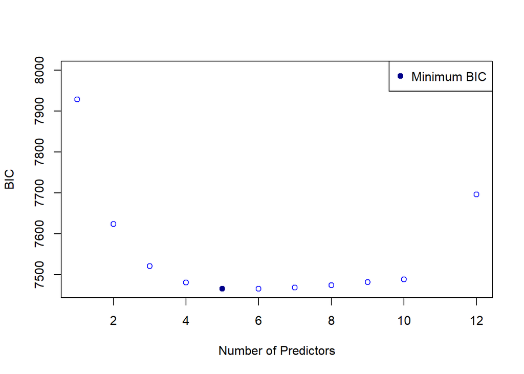

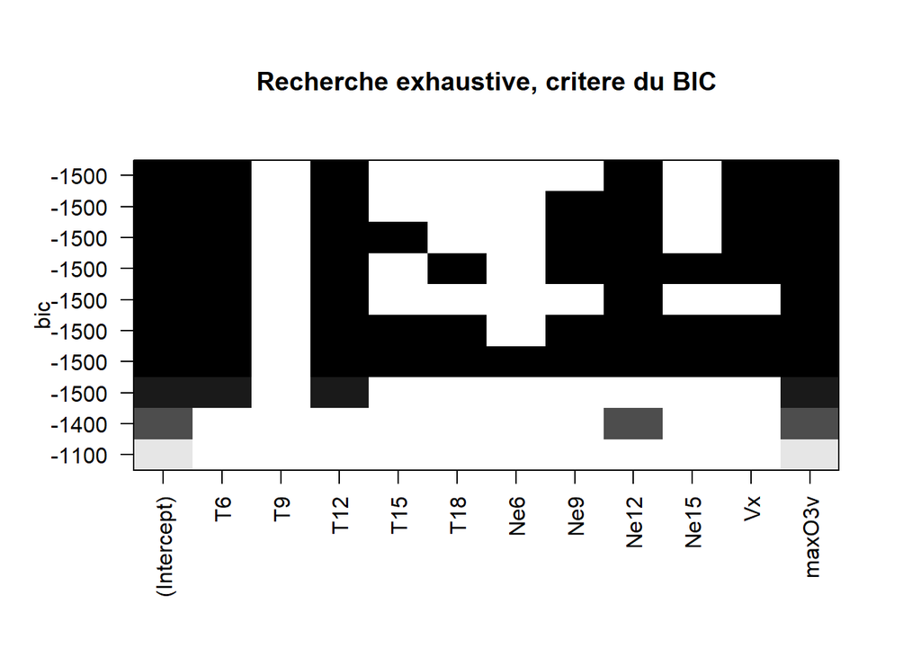

```r
plot(BIC ~ I(1:12), xlab="Number of Predictors", ylab="BIC", col="blue")


points(minBIC, BIC[minBIC], col="darkblue", pch=19)
legend("topright", legend="Minimum BIC", col="darkblue", pch=19)
```

- Pour le critère BIC, il faut spécifier l’option $\mathrm{k}=\log (\mathrm{n})$ :

```
## Start:  AIC=7503.25
## maxO3 ~ T6 + T9 + T12 + T15 + T18 + Ne6 + Ne9 + Ne12 + Ne15 +
##     Vx + maxO3v
##
##          Df Sum of Sq    RSS    AIC
## - T9      1         4 311482 7496.0
## - Ne6     1        40 311518 7496.2
## - T15     1        62 311540 7496.3
## - T18     1       101 311578 7496.5
## - Ne15    1       314 311791 7497.4
## - Ne9     1      1124 312602 7501.0
## - Ne12    1      1164 312642 7501.1
## <none>                311478 7503.3
## - T12     1      2500 313978 7507.0
## - Vx      1      3735 315213 7512.3
## - T6      1      7123 318600 7526.9
## - maxO3v  1    289086 600564 8392.9
##
## Step:  AIC=7496.05
## maxO3 ~ T6 + T12 + T15 + T18 + Ne6 + Ne9 + Ne12 + Ne15 + Vx +
##     maxO3v
##
##          Df Sum of Sq    RSS    AIC
## - Ne6     1        57 311538 7489.1
## - T15     1        61 311542 7489.1
## - T18     1       107 311589 7489.3
## - Ne15    1       313 311794 7490.2
## - Ne12    1      1206 312688 7494.1
## - Ne9     1      1255 312737 7494.3
## <none>                311482 7496.0
## - T12     1      3525 315007 7504.2
## - Vx      1      3731 315213 7505.1
## - T6      1     13019 324500 7544.8
## - maxO3v  1    289084 600565 8385.7
##
## Step:  AIC=7489.08
## maxO3 ~ T6 + T12 + T15 + T18 + Ne9 + Ne12 + Ne15 + Vx + maxO3v
##
##          Df Sum of Sq    RSS    AIC
## - T15     1        57 311596 7482.1
```

[output cut: 44 more lines]

```
## - Vx      1      4909 317765 7487.2
## - T6      1     14096 326952 7526.2
## - T12     1     24066 336922 7567.2
## - maxO3v  1    290526 603382 8363.2
##
## Step:  AIC=7473.16
## maxO3 ~ T6 + T12 + Ne12 + Vx + maxO3v
##
##          Df Sum of Sq    RSS    AIC
## <none>                314508 7473.2
## - Vx      1      5339 319848 7488.9
## - Ne12    1      8796 323304 7503.6
## - T6      1     20175 334683 7550.9
## - T12     1     32163 346671 7598.9
## - maxO3v  1    297582 612090 8375.5
```

- Dans ce cas, le modèle avec le BIC le plus bas est

$$\left(\mathcal{M}_{B I C}\right): \quad
\max O 3=\beta_0+\beta_1 * T 6+\beta_2 * T 12+\beta_3 * N e 12+\beta_4 *
V x+\beta_5 * \max O 3 v+\varepsilon$$

oü $BIC=7473.16$.

## Critère de la maximisation du $R^{2}_{a}$

- À partir du graphique suivant, nous pouvons voir que le modèle qui convient le mieux à nos données est celui qui comporte 8 variables (representer par darkblue), puisque c’est celui qui a la plus gran valeur pour R-squared adjusted:

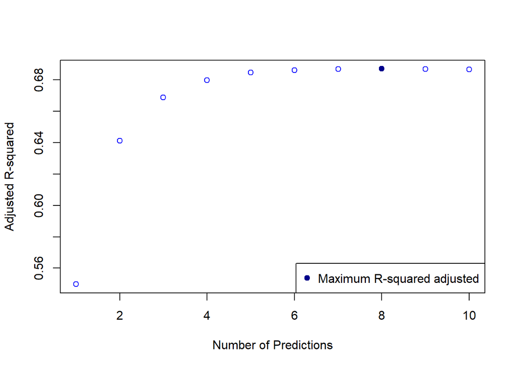

```r
maximo <- which.max(rs$adjr2)


plot(1:10, rs$adjr2, xlab="Number of Predictions", ylab="Adjusted R-squared", col="blue")
points(maximo, rs$adjr2[maximo], col="darkblue", pch=19)
legend("bottomright", legend="Maximum R-squared adjusted", col="darkblue", pch=19)
```

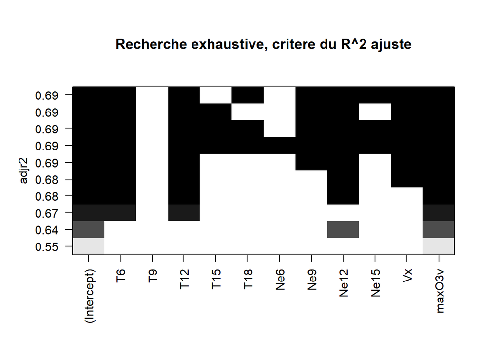

```r
plot(recherche.ex,scale="adjr2",main="Recherche exhaustive, critere du R^2 ajuste")
```

- Le modèle retenu est:

```
##  [1] 0.5498006 0.6413603 0.6687925 0.6797512 0.6848657 0.6862907 0.6869399
##  [8] 0.6870940 0.6869209 0.6867468
```

```
## [1] 0.687094
```

# Apprentissage-validation

Nous allons partager de façon aléatoire notre échantillon en deux sous-échantillons: échantillon d’apprentissage A (train) sur lequel nous allons entrainer notre modèle et l’échantillon de validation V (test) sur lequel nous allons tester le pouvoir prédictif du modèle

## Echantillon d’apprentissage A(train)

```
##      maxO3   T6   T9  T12  T15  T18 Ne6 Ne9 Ne12 Ne15      Vx maxO3v
## 1017  61.0  3.2  4.5  5.8  6.7  7.0   8   8    8    8  1.0419   61.0
## 679   86.4 10.2 11.3 13.8 12.1 10.1   7   6    5    6 -7.7942   90.0
## 129   44.2 16.3 21.8 27.2 28.4 24.3   5   6    7    7  3.0642   26.8
## 930   70.0 15.1 18.8 20.5 22.8 21.3   7   6    6    2 -1.7101   71.0
## 471  143.2 14.8 24.5 31.3 31.9 30.9   2   2    1    1  1.9696  151.4
## 299  114.6 15.9 25.9 30.7 31.1 29.9   1   1    3    3  1.7321   98.2
```

## Echantillon de validation V (test)

```
##    maxO3   T6   T9  T12  T15  T18 Ne6 Ne9 Ne12 Ne15       Vx maxO3v
## 1   56.0  8.6  9.5  6.8  9.1  7.7   6   3    6    7 -10.8329   59.6
## 2   39.2  3.6  5.6  9.2  8.4  4.9   3   4    6    7 -10.3366   56.0
## 4   41.2 11.8 11.8 11.0  7.0  7.7   8   7    6    7 -10.3366   36.0
## 9   45.4  5.0  8.2  8.8  7.7  6.1   7   7    6    7  -9.0000   53.8
## 10  49.2  6.2  6.4  7.4  9.7  8.5   8   6    7    6  -1.5628   45.4
## 12  50.4  4.0  9.8 12.3 13.2 10.6   9   5    7    7  -1.3681   50.0
```

## Entraine modele AIC

[output not shown]

[output cut: 912 more lines]

[output not shown]

## Entraine modele BIC

[output not shown]

[output cut: 850 more lines]

[output not shown]

[output not shown]

[output cut: 912 more lines]

[output not shown]

# Mean Squared Error

Sur l’échantillon de validation, nous allons calculer pour chaqu’un de ces trois modèles, l’erreur quadratique moyenne définie comme:

$$MSE=\frac{1}{n_V}
\sum_{i=1}^{n_V}\left(y_i-\hat{y}_i\right)^2$$

où $\hat{y}_{i}$ est la valeur prédite de $y_i$ pour i ∈ V un individu de l’échantillon de validation V . Cela veut dire que $\hat{y}_{i}=x_{i}^{\intercal} \hat{\beta}_{A}$ ou $x_{i}^{\intercal}$ est le vecteur de mesures des variables explicatives pour l’unité $i \in V$ et $\hat{\beta}_{A}$ est obtenu à partir de l’échantillon apprentissage qui ne contient pas l’unité $i$, donc l’unité $i$ n’a pas participé à la construction de $\hat{\beta}_{A}$.

## Fonction MSE

```r
MSE <- function(y, yhat) {
  mse <- 1/length(y)*(sum((y - yhat)^2))
  return(mse)
}
```

## Different Valeurs de MSE par le methodes

Dans ce cas, nous cherchons le modèle ayant le MSE le plus faible, et nous avons constaté que le minimum est représenté par $R_{a}^{2}$.

| Method | Mean Square Error |
| --- | --- |
| AIC | 236.4762 |
| BIC | 237.5783 |
| R-squared adjusted | 235.6883 |

## Graph de MSE

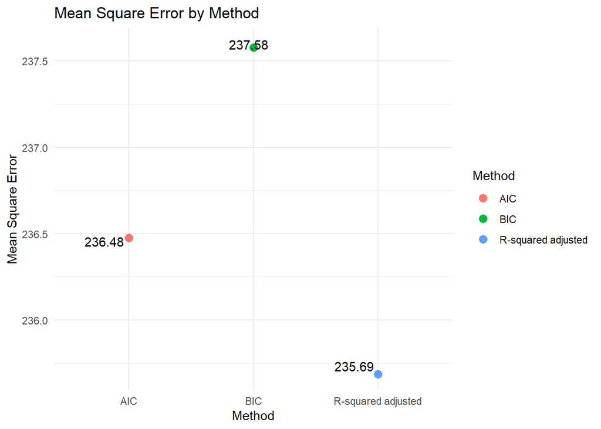

```r
ggplot(data, aes(x = Method, y = Mean_Square_Error)) +
  geom_point(size = 3, aes(color = Method)) +
  labs(title = "Mean Square Error by Method",
       x = "Method",
       y = "Mean Square Error")+
    geom_text(aes(label = round(Mean_Square_Error, 2)),
                         position = position_jitter(width = 0.2, height = 0.05))+
     geom_point(data = data[data$Method == "C",],
                          aes(x = Method, y = Mean_Square_Error),
                          size = 3, color = "red")+
    geom_text(data = data[data$Method == "C",],
                         aes(x = Method, y = Mean_Square_Error, label = "Method C"),
                         hjust = -0.2, size = 4, color = "red")+
    theme_minimal()
```

# Ajustement du jeu de données

On recommence las étapes de validation avec notre nouveau modèle:

## Le modele R-squared adjusted

```
##
## Call:
## lm(formula = maxO3 ~ T6 + T12 + T15 + Ne9 + Ne12 + Vx + maxO3v,
##     data = ozone)
##
## Residuals:
##     Min      1Q  Median      3Q     Max
## -68.112  -9.257   0.318   9.839  50.764
##
## Coefficients:
##             Estimate Std. Error t value Pr(>|t|)
## (Intercept) 25.88782    3.13162   8.267 3.25e-16 ***
## T6          -1.54395    0.19392  -7.962 3.56e-15 ***
## T12          1.25438    0.32390   3.873 0.000113 ***
## T15          0.55586    0.28446   1.954 0.050898 .
## Ne9         -0.76267    0.27078  -2.817 0.004924 **
## Ne12        -1.00299    0.29205  -3.434 0.000612 ***
## Vx           0.57431    0.13606   4.221 2.60e-05 ***
## maxO3v       0.58769    0.01652  35.573  < 2e-16 ***
## ---
## Signif. codes:  0 '***' 0.001 '**' 0.01 '*' 0.05 '.' 0.1 ' ' 1
##
## Residual standard error: 15.16 on 1358 degrees of freedom
## Multiple R-squared:  0.6885, Adjusted R-squared:  0.6869
## F-statistic: 428.9 on 7 and 1358 DF,  p-value: < 2.2e-16
```

## Residus en fonction de valeurs ajustés

Bien que nous puissions voir que les points ne présentent pas de schéma clair, nous ne pouvons pas conclure définitivement que le modèle correspond bien. C’est parce que nous devons encore évaluer si les résidus sont normalement distribués.

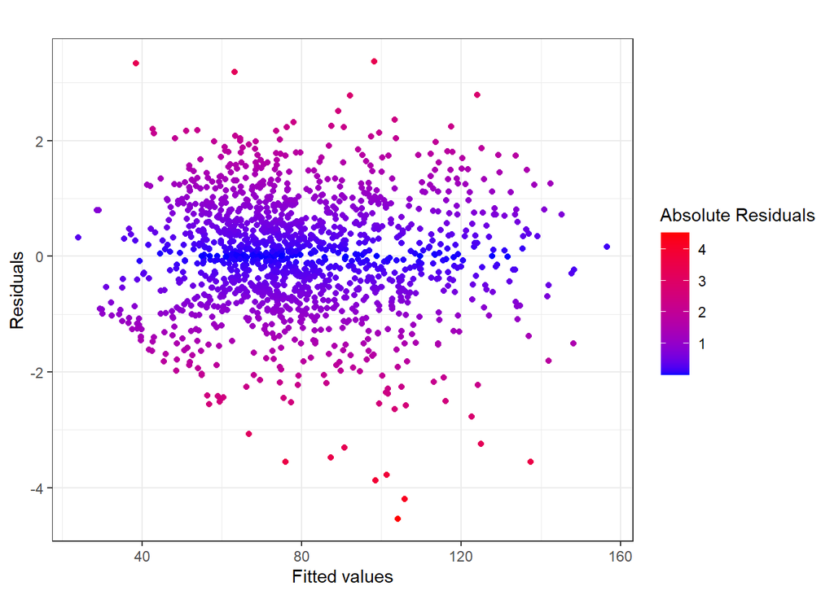

```r
ggplot(data.frame(residuals = rstudent(resfinal), fitted = fitted(resfinal)),
       aes(x = fitted, y = residuals, color = abs(residuals))) +
  geom_point() +
  scale_color_gradient(low = "blue", high = "red", name = "Absolute Residuals") +
  labs(x = "Fitted values", y = "Residuals",
       title = " ") +
  theme_bw()
```

## Normalite de Residus

Pour évaluer la normalité des résidus, nous allons générer un graphique QQ et corroborer les résultats avec les tests de Shapiro-Wilk et Kolmogorov-Smirnov.

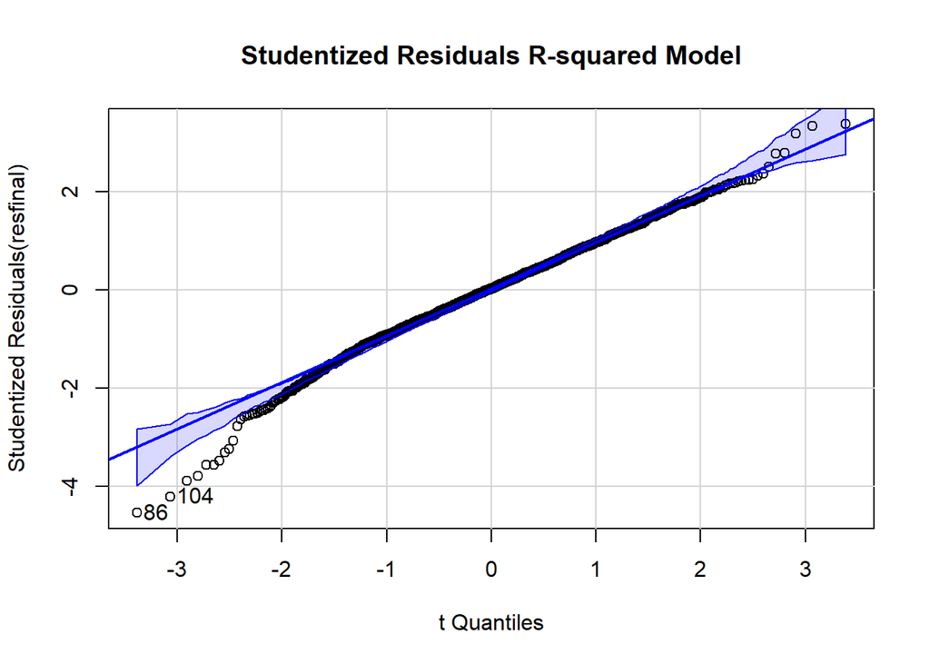

```
## [1]  86 104
```

D’après le QQ-plot, il semble qu’il y ait une queue inférieure où un nombre important de points s’écartent encore de la normalité. On peut donc en déduire que les résidus Studentized ne sont pas normalement distribués.

- Shapito Test for Normality

Laisser les hyphotesis nuls et alternatifs comme suit :

$$\begin{equation}
\begin{split}
H_{0} &: \text{les données sont normalement distribuées}\\
H_{1} &: \text{les données ne sont pas normalement distribuées}
\end{split}
\end{equation}$$

Nous effectuons un test Shapiro-Wilk pour tester la normalité des résidus comme suit

```
##
##  Shapiro-Wilk normality test
##
## data:  resifinal
## W = 0.9905, p-value = 9.828e-08
```

Puisque votre p-value de $9.828e-08$ est bien inférieure à $0.05$, nous pouvons en déduire qu’il existe des preuves solides pour rejeter l’hypothèse nulle et conclure que vos données ne suivent pas une distribution normale.

- Kolmogorov Test

```
##
##  Asymptotic one-sample Kolmogorov-Smirnov test
##
## data:  resifinal
## D = 0.43788, p-value < 2.2e-16
## alternative hypothesis: two-sided
```

La valeur p du test de Kolmogorov est inférieure à 0,05, ce qui indique que les données ne sont pas normalement distribuées.

## Studentized Residuals

Les résidus étudiés en dehors de la plage de $[−2,2]$ peuvent indiquer des valeurs aberrantes potentielles ou des observations influentes qui ont une plus grande incidence sur l’ajustement du modèle. (outliers).

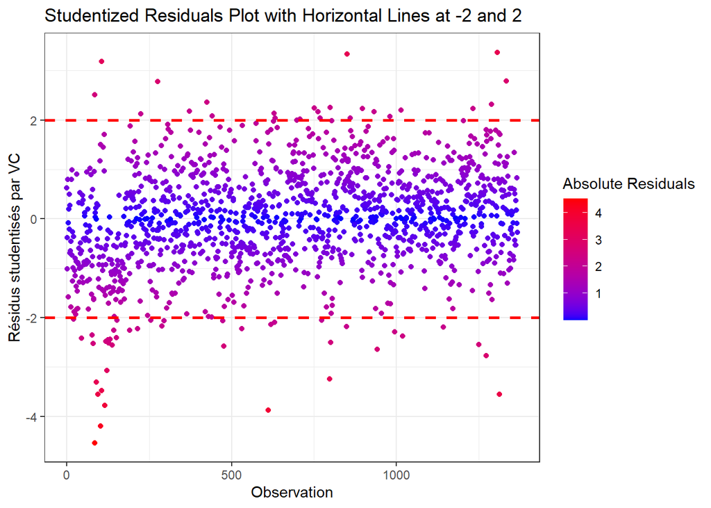

```r
ggplot(data.frame(residuals = rstudent(resfinal)), aes(x = seq_along(residuals), y = residuals, color = abs(residuals))) +
  geom_point() +
  geom_hline(yintercept = c(-2, 2), linetype = "dashed", color = "red", size = 1) +
  scale_color_gradient(low = "blue", high = "red", name = "Absolute Residuals") +
  labs(x = "Observation", y = "Résidus studentisés par VC", title = "Studentized Residuals Plot with Horizontal Lines at -2 and 2") +
  theme_bw()
```

## Histogram

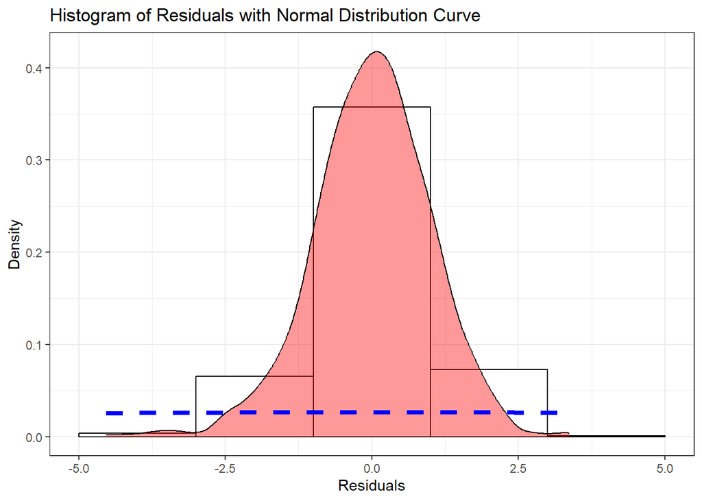

```r
#hist(residuals(res),xlab="residus d estimation",main="Histogramme des residus",breaks=20)
ggplot(data = data.frame(residuals = rstudent(resfinal)), aes(x = residuals)) +
  geom_histogram(binwidth = 2, aes(y = ..density..),
                 color = "black", fill = "white") +
  geom_density(alpha = 0.4, fill = "red") +
  stat_function(fun = dnorm, args = list(mean = mean(residuals(res)), sd = sd(residuals(res))), color = "blue", linetype = "dashed", size = 1.5) +
  labs(x = "Residuals", y = "Density", title = "Histogram of Residuals with Normal Distribution Curve") +
  theme_bw()
```

## Comparison Distance de Cook dans le deux Modele

- D’après cette comparaison, nous pouvons constater que le point ayant la plus grande distance de Cook dans le nouveau modèle est passé de l’individu 104 à 627.

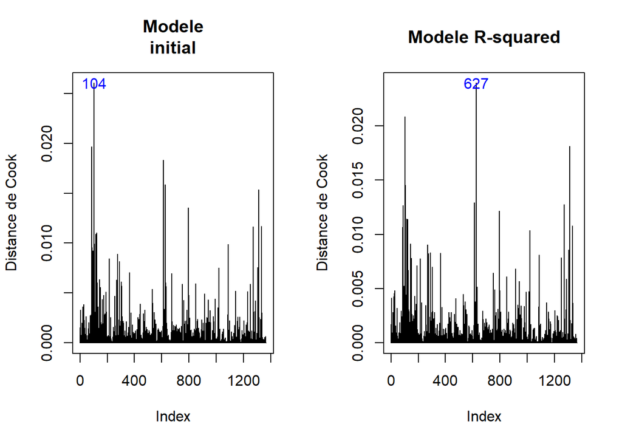

```r
par(mfrow=c(1,2))
maximumcook <- which.max(cooks.distance(res))
plot(cooks.distance(res),type="h",ylab="Distance de Cook",main = "Modele
initial")
text(maximumcook, cooks.distance(res)[maximumcook], row.names(ozone)[maximumcook], col="blue")
maximumcook <- which.max(cooks.distance(resfinal))
plot(cooks.distance(resfinal),type="h",ylab="Distance de Cook",main = "Modele R-squared")
text(maximumcook, cooks.distance(resfinal)[maximumcook], row.names(ozone)[maximumcook], col="blue")
```

- Test de Breusch-Pagan par heteroscedasticity

$$\begin{equation}
\begin{split}
H_{0} &: \text{the variance of the errors is constant
(homoscedasticity)}\\
H_{1} &: \text{the variance of the errors is not constant
(heteroscedasticity)}
\end{split}
\end{equation}$$

```
##
##  studentized Breusch-Pagan test
##
## data:  resfinal
## BP = 36.504, df = 7, p-value = 5.823e-06
```

puisque les p-valeurs est 5.823e-06 moins que 0.05, nous rejetons l’hypothèse nulle et concluons qu’il y a des preuves d’hétéroscédasticité.

# Removing the outliers

Nous remarquons que même si nous choisissons le meilleur modèle en choisissant celui qui a le MSE minimum, nous n’avons toujours pas obtenu la normalité dans les résidus, pour cette raison Nous allons supprimer les points qui ont des résidus standardisés en dehors de l’intervalle $[-3,3]$, ce qui signifie ce qui suit et si nous atteignons la normalité, Nous allons poursuivre notre analyse.

## Standardized Residuals

Nous supprimerons le point qui a des résidus standardisés en dehors de l’intervalle $[-3,3]$, ce qui signifie les valeurs qui sont en dehors des lignes rouges pointées

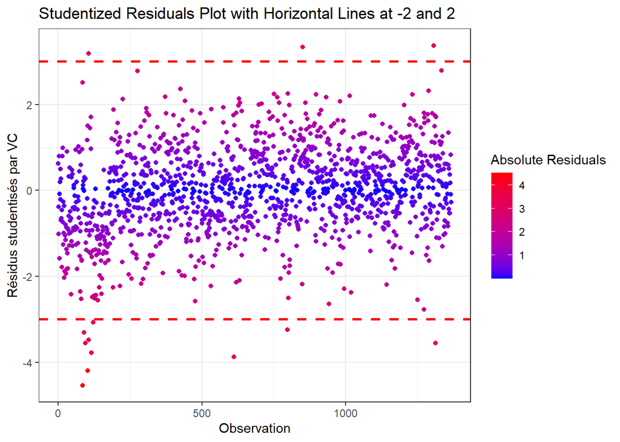

```r
ggplot(data.frame(residuals = rstudent(resfinal)), aes(x = seq_along(residuals), y = residuals, color = abs(residuals))) +
  geom_point() +
  geom_hline(yintercept = c(-3, 3), linetype = "dashed", color = "red", size = 1) +
  scale_color_gradient(low = "blue", high = "red", name = "Absolute Residuals") +
  labs(x = "Observation", y = "Résidus studentisés par VC", title = "Studentized Residuals Plot with Horizontal Lines at -2 and 2") +
  theme_bw()
```

## New Model (without the Outliers)

Nous considérons le même modèle où nous remontons des données de outliers

```
##
## Call:
## lm(formula = maxO3 ~ T6 + T12 + T15 + Ne9 + Ne12 + Vx + maxO3v,
##     data = ozone2)
##
## Residuals:
##     Min      1Q  Median      3Q     Max
## -43.516  -9.263   0.247   9.450  42.233
##
## Coefficients:
##             Estimate Std. Error t value Pr(>|t|)
## (Intercept) 24.44014    2.97387   8.218 4.80e-16 ***
## T6          -1.42621    0.18362  -7.767 1.58e-14 ***
## T12          1.03055    0.30544   3.374 0.000762 ***
## T15          0.70193    0.26865   2.613 0.009080 **
## Ne9         -0.75445    0.25574  -2.950 0.003232 **
## Ne12        -1.07004    0.27614  -3.875 0.000112 ***
## Vx           0.50293    0.12825   3.921 9.24e-05 ***
## maxO3v       0.61206    0.01576  38.835  < 2e-16 ***
## ---
## Signif. codes:  0 '***' 0.001 '**' 0.01 '*' 0.05 '.' 0.1 ' ' 1
##
## Residual standard error: 14.25 on 1345 degrees of freedom
## Multiple R-squared:  0.7213, Adjusted R-squared:  0.7199
## F-statistic: 497.3 on 7 and 1345 DF,  p-value: < 2.2e-16
```

## Corplot

De la comparaison des graphiques de corrélation, il semble qu’il n’y ait pas de différence significative entre eux. Cependant, il est important de noter que lorsqu’on analyse les données complètes, les résidus ne suivent pas une distribution normale. En revanche, lorsque les valeurs aberrantes sont supprimées, les résidus tendent à présenter une normalité. Par conséquent, la suppression des valeurs aberrantes peut améliorer la qualité de l’analyse en rendant l’hypothèse de normalité plus plausible.

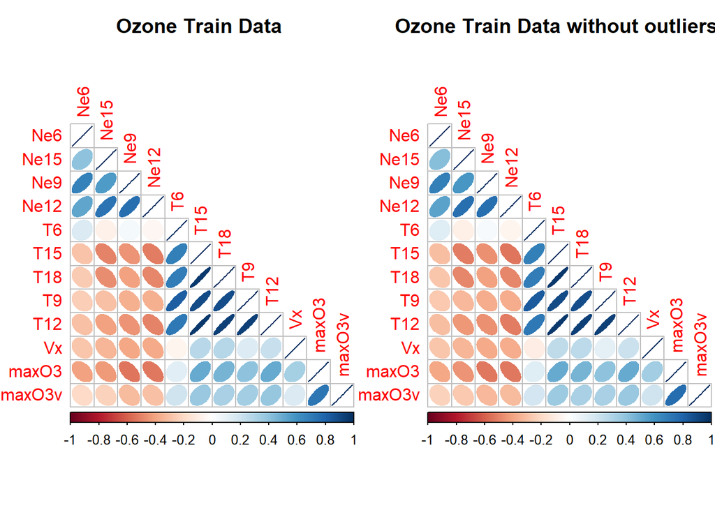

## Studentized Residuals

Les résidus studentisés ont le graphique suivant:

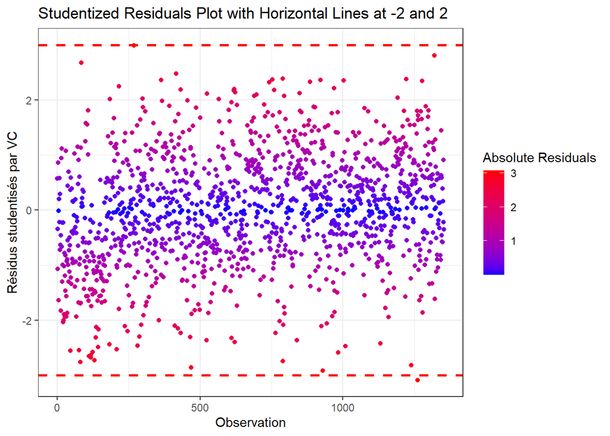

```r
ggplot(data.frame(residuals = rstudent(resfinal1)), aes(x = seq_along(residuals), y = residuals, color = abs(residuals))) +
  geom_point() +
  geom_hline(yintercept = c(-3, 3), linetype = "dashed", color = "red", size = 1) +
  scale_color_gradient(low = "blue", high = "red", name = "Absolute Residuals") +
  labs(x = "Observation", y = "Résidus studentisés par VC", title = "Studentized Residuals Plot with Horizontal Lines at -2 and 2") +
  theme_bw()
```

## Normality Comparison

Nous pouvons maintenant voir une différence par rapport au QQ-plot dans le modèle initial et dans les modèles finaux où nous supprimons les valeurs aberrantes. Nous poursuivrons notre analyse avec ce modèle.

```
## [1]  86 104
```

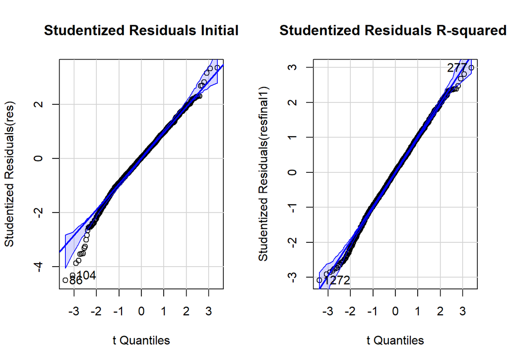

```
##  277 1272
##  269 1261
```

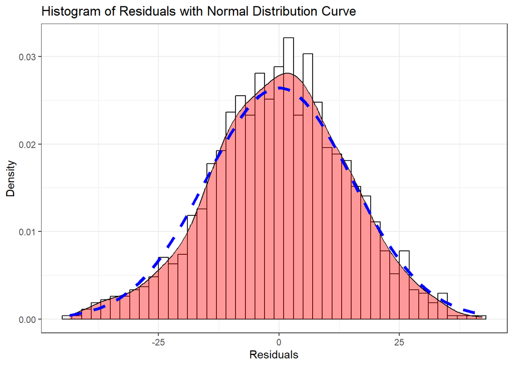

```r
#hist(residuals(res),xlab="residus d estimation",main="Histogramme des residus",breaks=20)
par(mfrow=c(1,2))
ggplot(data = data.frame(residuals = residuals(resfinal1)), aes(x = residuals)) +
  geom_histogram(binwidth = 2, aes(y = ..density..),
                 color = "black", fill = "white") +
  geom_density(alpha = 0.4, fill = "red") +
  stat_function(fun = dnorm, args = list(mean = mean(residuals(res)), sd = sd(residuals(res))), color = "blue", linetype = "dashed", size = 1.5) +
  labs(x = "Residuals", y = "Density", title = "Histogram of Residuals with Normal Distribution Curve") +
  theme_bw()
```

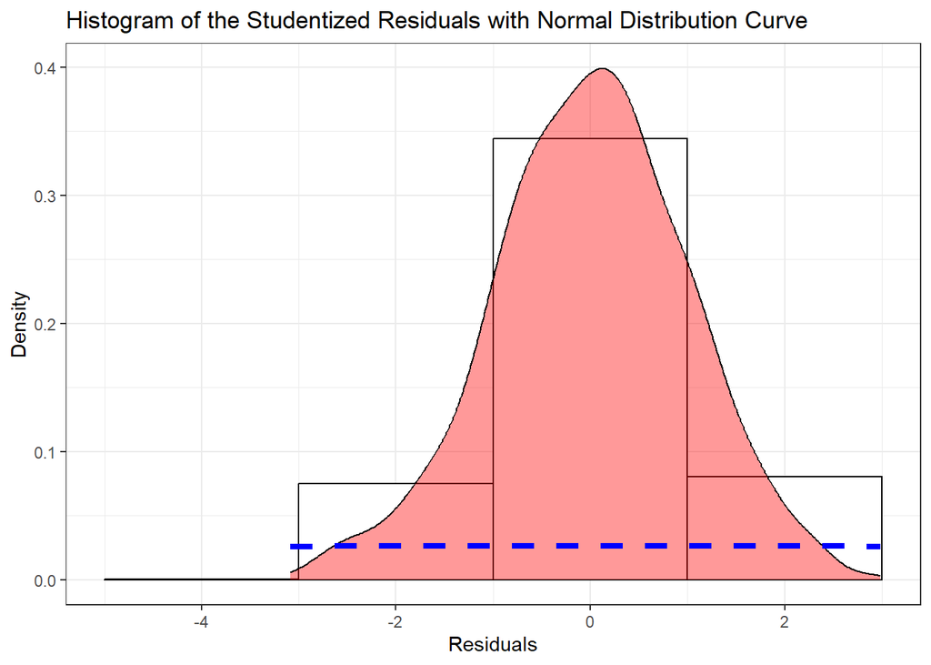

```r
ggplot(data = data.frame(residuals = rstudent(resfinal1)), aes(x = residuals)) +
  geom_histogram(binwidth = 2, aes(y = ..density..),
                 color = "black", fill = "white") +
  geom_density(alpha = 0.4, fill = "red") +
  stat_function(fun = dnorm, args = list(mean = mean(residuals(res)), sd = sd(residuals(res))), color = "blue", linetype = "dashed", size = 1.5) +
  labs(x = "Residuals", y = "Density", title = "Histogram of the Studentized Residuals with Normal Distribution Curve") +
  theme_bw()
```

## Comparison Distance de Cook dans le deux Modele

En se basant sur le graphique, il est évident que l’individu 627 présente toujours une distance de Cook plus élevée dans le R carré et le R carré sans les valeurs aberrantes, tandis que le nombre de points de forte influence a diminué.

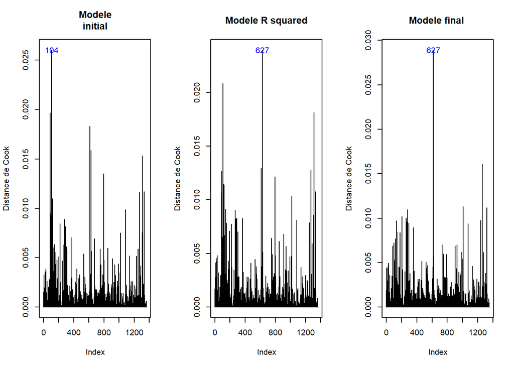

# Conclusion

- Dans les grands échantillons (p. ex., lorsque le nombre d’observations par variable est supérieur à 10), les violations de cette hypothèse de normalité n’ont souvent pas d’incidence notable sur les résultats.
- Nous avons sélectionné le meilleur modèle en fonction du coefficient de détermination ajusté (R carré ajusté), car il a donné la valeur la plus faible pour l’erreur quadratique moyenne (MSE).
- La suppression des valeurs aberrantes peut améliorer la normalité des résidus, ce qui est une hypothèse importante pour de nombreuses analyses statistiques.

# Questions

- Comment nous pouvons supprimer certaines personnes afin d’obtenir des résidus normaux?
- Pourquoi obtient-on des résultats indiquant que les résidus ne suivent pas une distribution normale selon les tests de Shapiro ou de Kolmogorov, alors que le QQ-plot montre que les résidus suivent une distribution normale ?
- Puis-je utiliser le test Breusch-Pagan pour vérifier l’hétéroscédasticité de mes données ?